# ACP - TD

Dans ce TD, nous aborderons la réalisation de l’ACP sous R. Vous devez exécuter l’ensemble des commandes réalisées ici (et les comprendre), afin de pouvoir les reproduire.

En plus des packages présentés ci-dessous, nous devrons utiliser d’autres packages (inclus dans le chargement du package `tidyverse`) pour réaliser les graphiques et autres tableaux.

```r
library(tidyverse)
library(stringr)
```

## Package `FactoMiner`

Nous allons voir comment utiliser le package [`FactoMineR`](http://factominer.free.fr/) pour réaliser les calculs de l’ACP. Ce package est très complet et nous retourne tes les informations nécessaires.

### Données `decathlon`

En premier lieu, on doit charger la librairie (voire l’installer si ce n’est pas déjà fait). Nous allons utiliser le jeu de données [`decathlon`](https://rdrr.io/cran/FactoMineR/man/decathlon.html).

```r
library(FactoMineR)
data(decathlon)
```

### Calcul de l’ACP

Ici, nous ne voulons pas les graphiques tout de suite.

```r
acp = PCA(decathlon[,1:10], graph = FALSE)
```

L’objet renvoyé est une liste avec toutes les informations importantes.

```r
names(acp)
```

```
[1] "eig"  "var"  "ind"  "svd"  "call"
```

Le contenu de cet objet est plutôt bien détaillé (mais en anglais) lorsqu’on l’affiche.

```r
acp
```

```
**Results for the Principal Component Analysis (PCA)**
The analysis was performed on 41 individuals, described by 10 variables
*The results are available in the following objects:

   name               description
1  "$eig"             "eigenvalues"
2  "$var"             "results for the variables"
3  "$var$coord"       "coord. for the variables"
4  "$var$cor"         "correlations variables - dimensions"
5  "$var$cos2"        "cos2 for the variables"
6  "$var$contrib"     "contributions of the variables"
7  "$ind"             "results for the individuals"
8  "$ind$coord"       "coord. for the individuals"
9  "$ind$cos2"        "cos2 for the individuals"
10 "$ind$contrib"     "contributions of the individuals"
11 "$call"            "summary statistics"
12 "$call$centre"     "mean of the variables"
13 "$call$ecart.type" "standard error of the variables"
14 "$call$row.w"      "weights for the individuals"
15 "$call$col.w"      "weights for the variables"
```

### Variance expliquée

L’objet `eig` est une `matrix`, contenant pour chaque composante :

- la valeur propre
- le pourcentage de variance expliquée
- le pourcentage cumulé de variance expliquée

```r
acp$eig
```

```
        eigenvalue percentage of variance
comp 1   3.2719055              32.719055
comp 2   1.7371310              17.371310
comp 3   1.4049167              14.049167
comp 4   1.0568504              10.568504
comp 5   0.6847735               6.847735
comp 6   0.5992687               5.992687
comp 7   0.4512353               4.512353
comp 8   0.3968766               3.968766
comp 9   0.2148149               2.148149
comp 10  0.1822275               1.822275
        cumulative percentage of variance
comp 1                           32.71906
comp 2                           50.09037
comp 3                           64.13953
comp 4                           74.70804
comp 5                           81.55577
comp 6                           87.54846
comp 7                           92.06081
comp 8                           96.02958
comp 9                           98.17773
comp 10                         100.00000
```

On peut donc produire le graphique de la variance expliquée, par composante. Remarquez que le graphique des valeurs propres donnent exactement le même graphique, à l’échelle des ordonnées près (*à tester*).

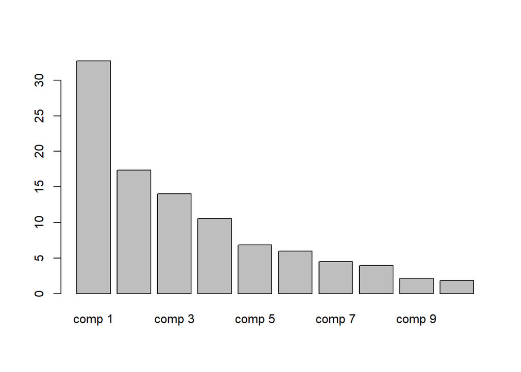

```r
barplot(acp$eig[,2])
```

On peut aussi montrer la variance expliquée cumulée.

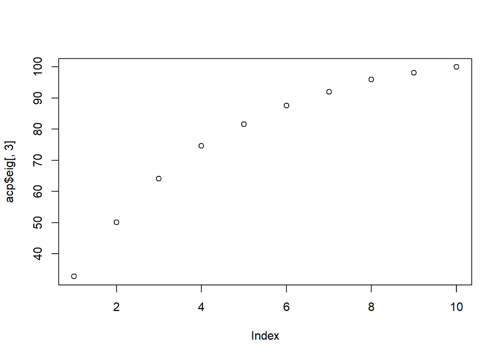

```r
plot(acp$eig[,3])
```

*A faire* : représenter dans un même graphique les deux informations comme ci-dessous par exemple.

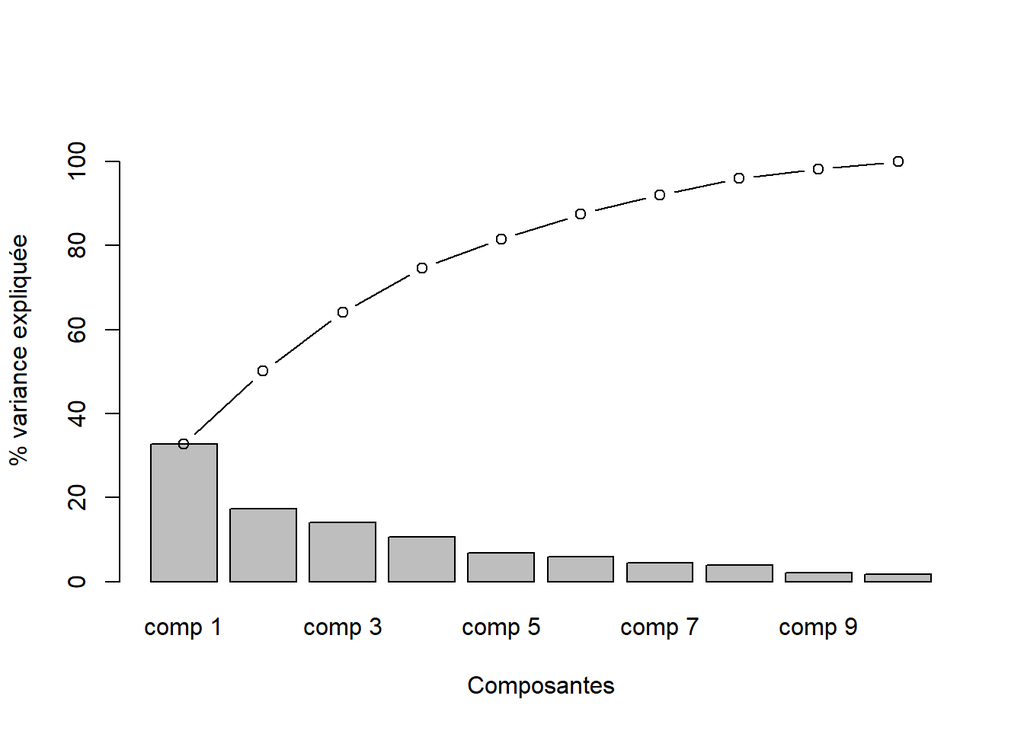

ou

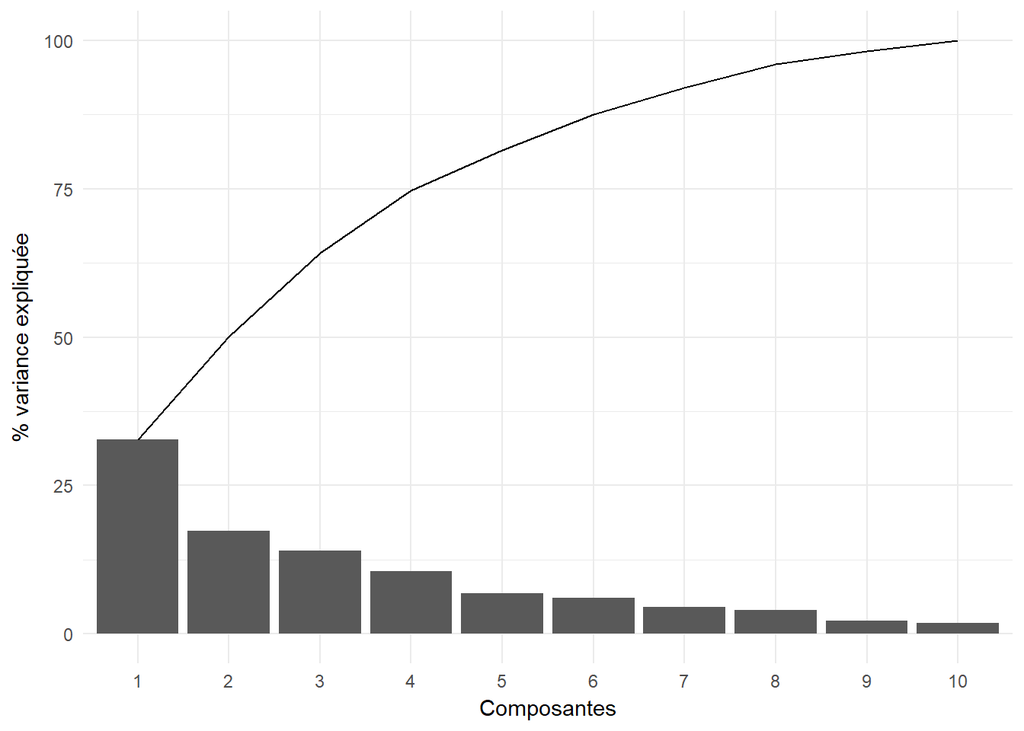

### Représentation graphique

#### Individus

Par défaut, lorsqu’on utilise la fonction `plot()` sur l’objet obtenu, on obtient le *premier plan factoriel*, avec les 2 premières composantes.

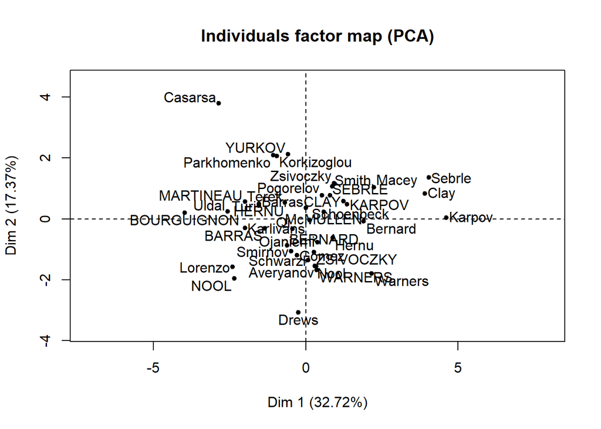

```r
plot(acp)
```

Si on veut choisir les composantes à représenter, nous utilisons le paramètre `axes`.

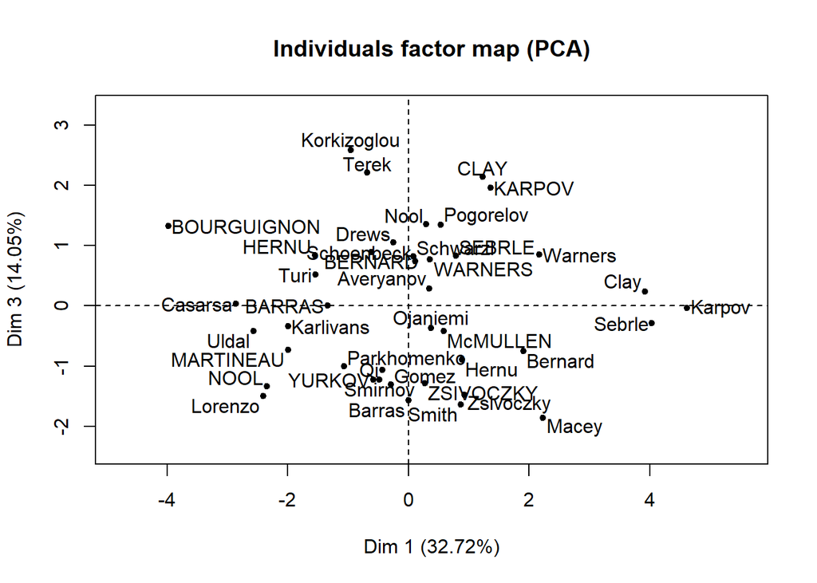

```r
plot(acp, axes = c(1, 3))
```

#### Variables

Pour obtenir le cercle de corrélation (si ACP normée), il faut afficher que le paramètre `choix` est égal à `"var"`. Ce sont toujours les 2 premières composantes par défaut (et la syntaxe est la même pour changer les composantes).

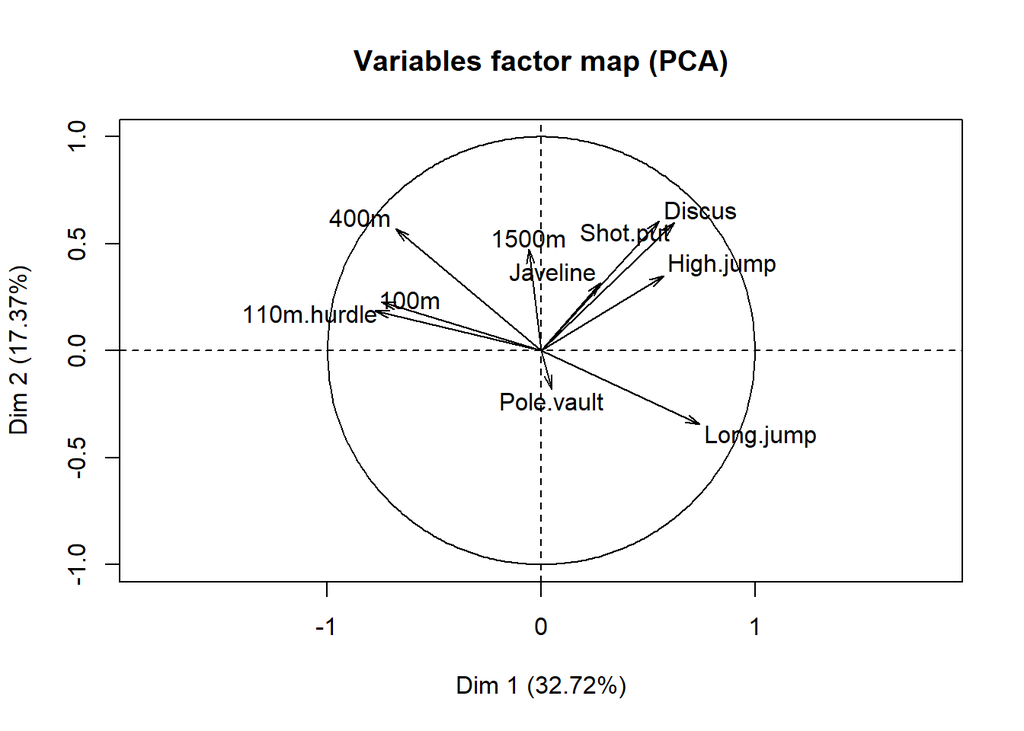

```r
plot(acp, choix = "var")
```

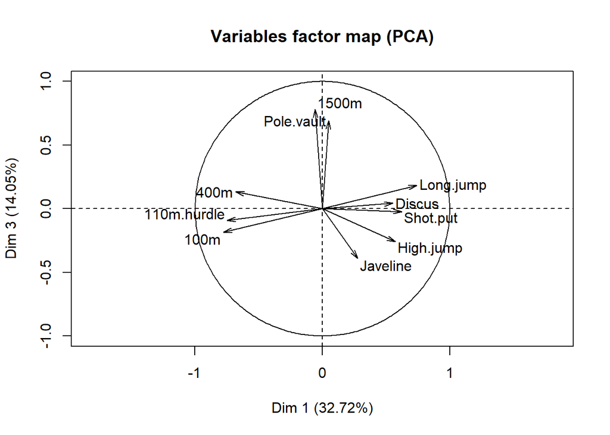

```r
plot(acp, choix = "var", axes = c(1, 3))
```

### Contributions et qualité de représentation

Il est possible d’obtenir la contribution de chaque individu dans l’objet `contrib`, lui-même dans l’objet `ind` du résultat de la fonction. Idem pour les variables (sous-objet `contrib` dans l’objet `var`).

Pour la qualité de représentation, celle-ci est stockée dans le sous-objet `cos2` (de `ind` pour les individus et de `var` pour les variables).

Bien évidemment, tous les afficher seraient difficile à lire, particulièrement pour les individus. Il faut donc se restreindre à ceux ayant une forte valeur, et ce pour chaque axe.

Pour l’axe 1, nous pourrions faire ainsi :

- Sélectionner les individus ayant une contribution supérieure à $\frac{1}{n}$ (voire plutôt $\frac{2}{n}$ ou $\frac{3}{n}$)
- Sélectionner les individus ayant une qualité de représentation supérieure à $\frac{1}{p}$
- Joindre les deux (en gardant toutes les lignes : *jointure extérieure* - le *SQL* n’est jamais très loin…)

(On peut aussi procéder autrement pour créer ce tableau final.)

```r
ind.contrib.1 = subset(data.frame(acp$ind$contrib),
                       subset = Dim.1 > (300/nrow(decathlon)),
                       select = "Dim.1")
ind.cos2.1 = subset(data.frame(acp$ind$cos2),
                    subset = Dim.1 > (1/ncol(decathlon)),
                    select = "Dim.1")
merge(setNames(ind.contrib.1, "Contribution"),
      setNames(ind.cos2.1, "Qualite"),
      by = "row.names", all = T)
```

```
     Row.names Contribution    Qualite
1       BARRAS           NA 0.47246875
2      Bernard           NA 0.45463659
3  BOURGUIGNON     11.80246 0.85684159
4      Casarsa           NA 0.33710428
5         Clay     11.45109 0.71120519
6         CLAY           NA 0.12400941
7        Hernu           NA 0.23751328
8        HERNU           NA 0.30610405
9    Karlivans           NA 0.54390014
10      Karpov     15.91098 0.85175530
11      KARPOV           NA 0.15991886
12     Lorenzo           NA 0.47080051
13       Macey           NA 0.42304864
14   MARTINEAU           NA 0.28430072
15        NOOL           NA 0.39434639
16 Parkhomenko           NA 0.09413024
17      Sebrle     12.15751 0.69541021
18      SEBRLE           NA 0.11167888
19        Turi           NA 0.25246366
20       Uldal           NA 0.75660156
21     Warners           NA 0.52994371
22   Zsivoczky           NA 0.12999794
```

Il faut faire de même pour les variables (*à tester*).

*A faire* : Rédiger un programme permettant de sortir les variables importantes pour chaque dimension retenue, comme ci-dessous par exemple.

```
--------------------------------------------------
 Dim.1

          var contrib qualite
1        100m      18      60
2   Long.jump      17      55
3    Shot.put      12      39
4   High.jump      10      33
5        400m      14      46
6 110m.hurdle      17      56
7      Discus       9      31


--------------------------------------------------
 Dim.2

        var contrib qualite
3  Shot.put      21      36
5      400m      19      32
7    Discus      21      37
10    1500m      13      22


--------------------------------------------------
 Dim.3

          var contrib qualite
8  Pole.vault      34      48
9    Javeline      11      15
10      1500m      44      61


--------------------------------------------------
 Dim.4

          var contrib qualite
6 110m.hurdle       8       8
8  Pole.vault      29      30
9    Javeline      48      51


--------------------------------------------------
 Dim.5

         var contrib qualite
1       100m      13       9
4  High.jump      45      31
8 Pole.vault      16      11
9   Javeline      14       9
```

### Interprétation

#### Nombre de composantes

Si nous regardons les valeurs propres, nous remarquons qu’il y en 4 supérieures à 1 (critère de Kaiser). Par contre, avec 2 composantes, nous expliquons 50% de l’information, et 64% avec 3 axes.

#### Axe 1

7 épreuves sont importantes pour la première composante :

- *courses courtes* : 100m, 400m, 110m haies (sur la gauche de l’axe) ;
- *sauts/lancer* : saut en hauteur, saut en longueur, lancer du poids et du disque (sur la droite).

Cet axe résume la performance des décathloniens sur une épreuve, avec les meilleurs ayant des coordonnées les plus élevés (avec des valeurs fortes pour les sauts et lancers, et faibles pour les courses).

Nous pouvons donc noter les très bonnes performances de trois décathloniens (Karpov, puis Sebrie et Clay), au Jeux Olympiques. Par contre, BOURGUIGNON, au Decastar, a réalisé la plus mauvaise performance.

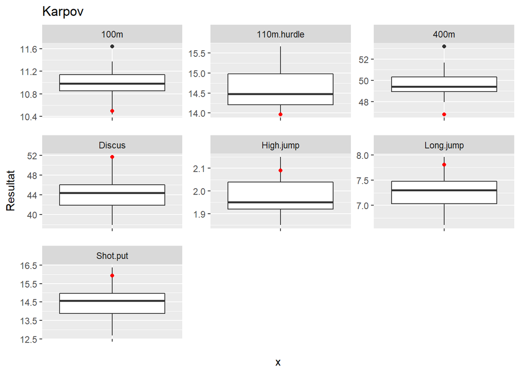

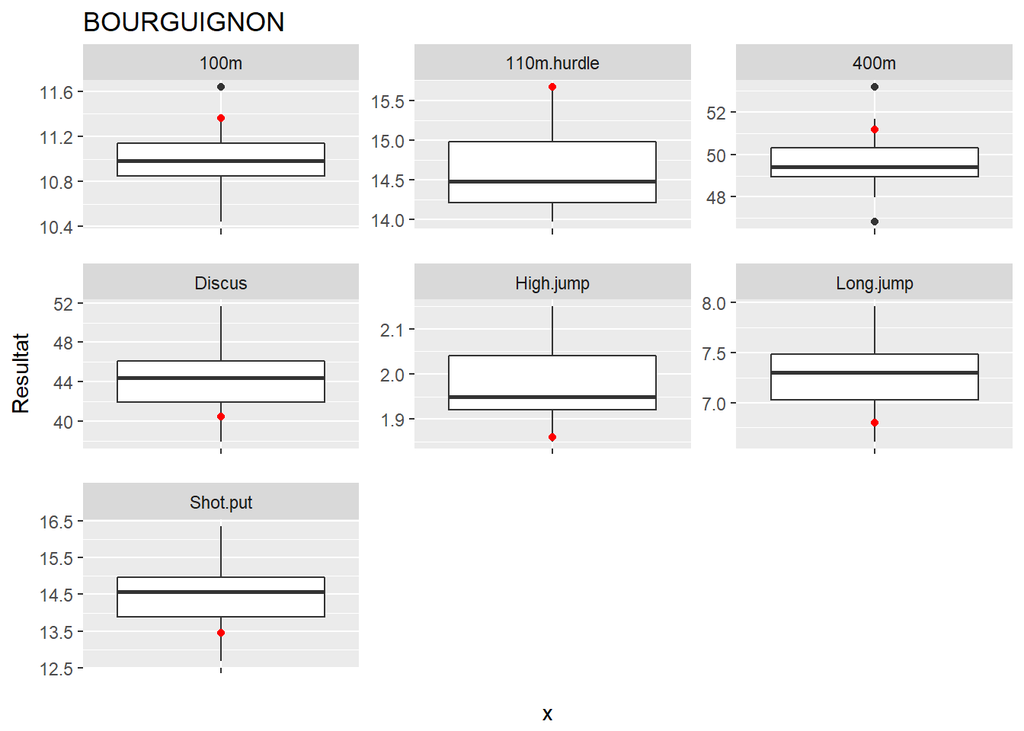

#### Axe 2

Ici, seulement 4 variables sont importantes :

- *courses longues* : 400m et 1500m (sur le haut de l’axe) ;
- *lancers* : poids et disque (aussi en haut de l’axe).

Cet axe doit opposer deux styles d’athlètes : ceux plutôt orientés vers les lancers (en haut de l’axe), et ceux plutôt orientés vers les courses longues.

Par exemple, Casarsa a réalisé le plus mauvais temps au 400m et un temps élevéau 1500m, mais a réussi des lancers de poids et de disque plutôt bons.

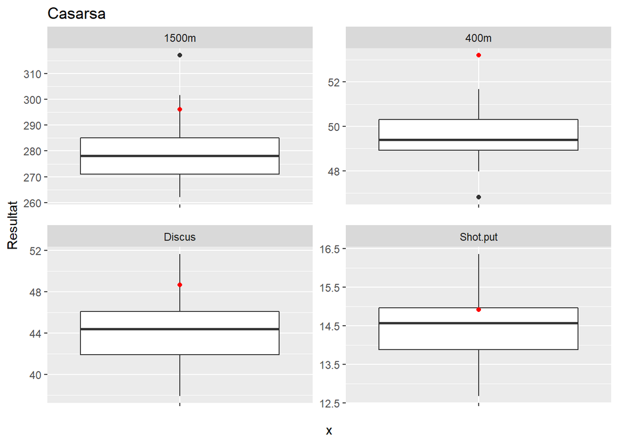

Au contraire, les performances de Drews aux lancers sont faibles, mais ses temps au 400m et 1500m sont bons.

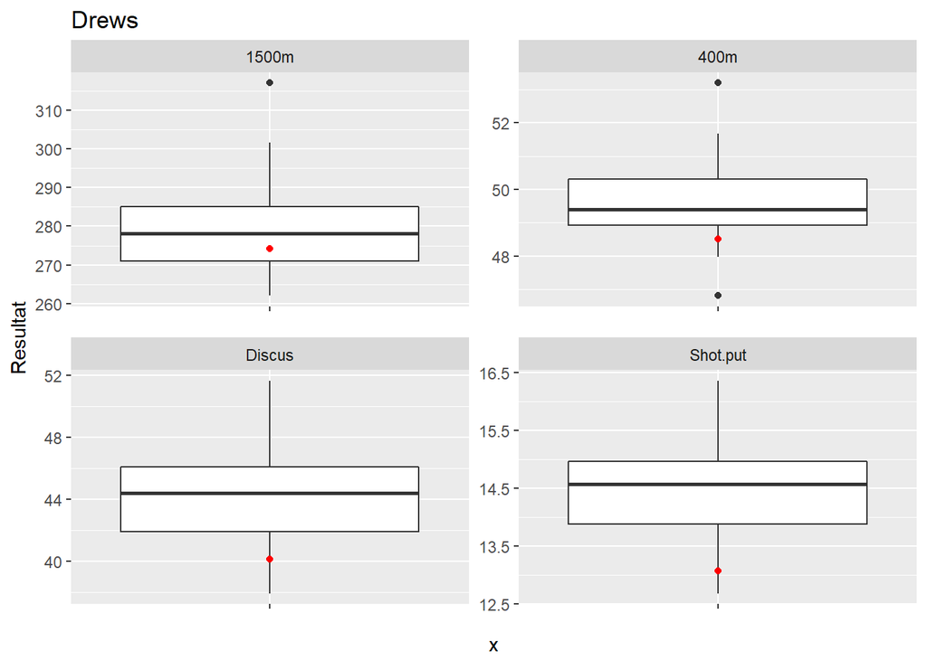

#### Axe 3

Sur cet axe, les variables retenues sont au nombre de trois et assez disparatre :

- saut à la perche et 1500m en haut de l’axe
- javelot de l’autre côté (mais de manière assez faible finalement)

Idem que pour l’axe 2, celui-ci semble opposé des styles de sportifs.

Korkizoglou a réussi le plus mauvais temps au 1500m, et une performance très moyenne au saut à la perche (ainsi qu’au javelot).

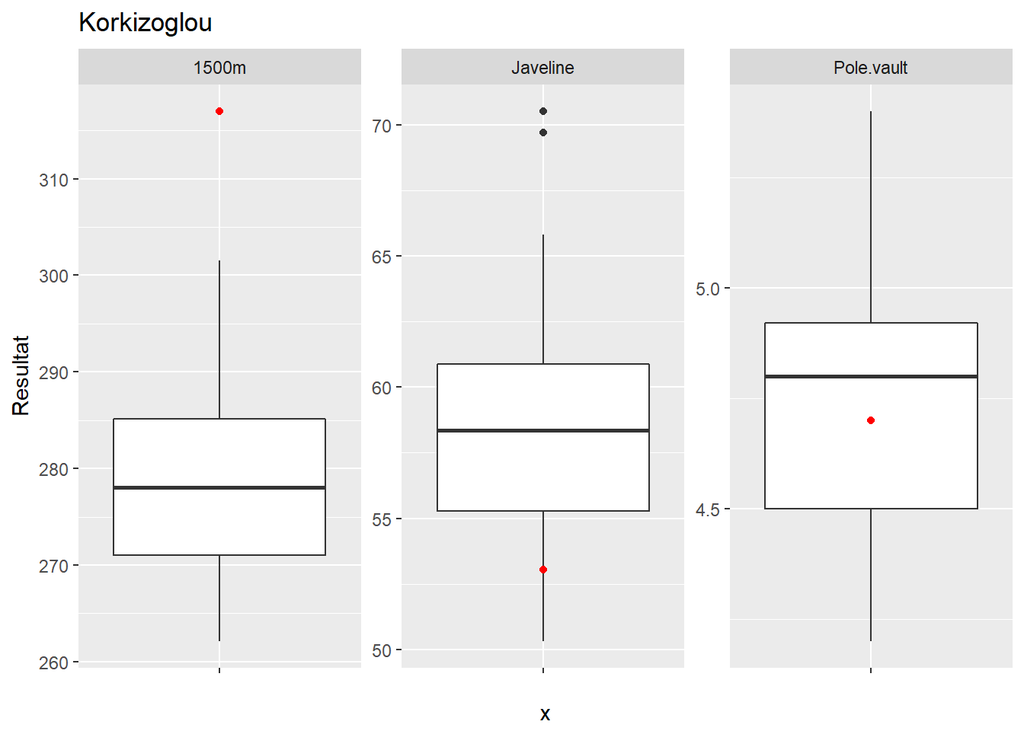

```r
affIndividu("Korkizoglou", varimp[[3]])
```

On voit bien que Macey n’a pas réussi de saut très haut à la perche, alors que son temps au 1500m est très bon.

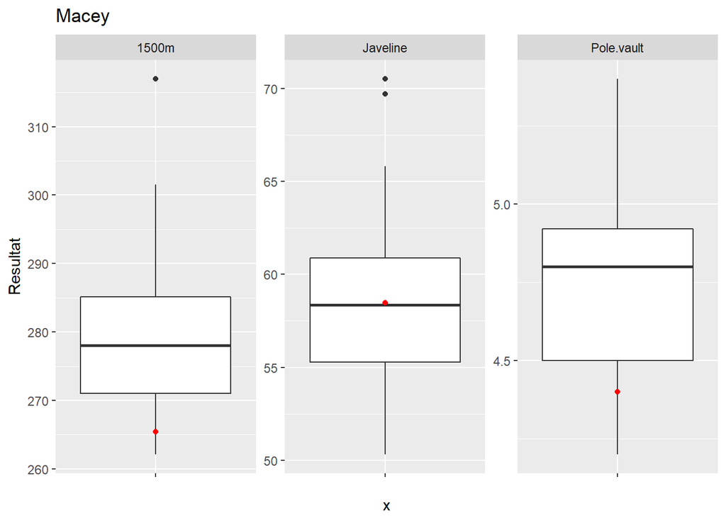

```r
affIndividu("Macey", varimp[[3]])
```

## FactoInvestigate

En plus du package `FactoMineR`, il existe le package [`FactoInvestigate`](http://factominer.free.fr/reporting/index_fr.html) qui permet de créer un rapport automatique pour l’interprétation d’un résultat d’une fonction de `FactoMineR` (ici, de `PCA()` donc).

Voila comment lancer la création du rapport.

```r
library(FactoInvestigate)
Investigate(acp, file = "Investigate-ACP.Rmd")
```

## Package `Factoshiny`

Dans le même état d’esprit, le package [`Factoshiny`](http://factominer.free.fr/graphs/factoshiny-fr.html) permet lui de lancer une application dans un navigateur web pour réaliser une analyse des résultats, ainsi que pour exporter des graphiques et récupérer des tableaux. Voici comment lancer l’application :

```r
library(Factoshiny)
PCAshiny(acp)
```

## A faire

Merci de produire un document `Rmarkdown` contenant l’ensemble du code et des commentaires.

### Worldwide Governance Indicators

La [banque mondiale](http://www.banquemondiale.org) fournit un grand nombre de données, dont des indicateurs de gouvernance au niveau mondial (voir [ici](https://data.worldbank.org/data-catalog/worldwide-governance-indicators)). Le code ci-dessous importe les données du fichier `WGI_Data.csv` (que vous devez donc télécharger) pour les importer. Les informations concernant la définition des indicateurs et leur source se trouvent dans le fichier `WGI_Definition and Source.csv`.

```r
wgi.m = read_csv("WGI_Data.csv", quote = '"') %>%
  mutate_at("Value", funs(as.numeric))
wgi = wgi.m %>%
  select(`Country Name`, `Series Code`, Value) %>%
  spread(`Series Code`, Value) %>%
  rename_at(vars(ends_with("EST")), funs(sub(".EST", "", .)))
```

| Country Name | CC | GE | PV | RL | RQ | VA |
| --- | --- | --- | --- | --- | --- | --- |
| Afghanistan | -1.56 | -1.22 | -2.75 | -1.62 | -1.33 | -1.09 |
| Albania | -0.40 | 0.00 | 0.26 | -0.35 | 0.19 | 0.16 |
| Algeria | -0.69 | -0.54 | -1.14 | -0.85 | -1.17 | -0.88 |
| American Samoa | 1.23 | 0.53 | 1.19 | 1.33 | 0.14 | NA |
| Andorra | 1.23 | 1.86 | 1.40 | 1.56 | 0.87 | 1.20 |
| Angola | -1.41 | -1.04 | -0.39 | -1.08 | -1.00 | -1.17 |

Vous devez donc réaliser les étapes suivantes :

- Décrire rapidement les données
- Réaliser une ACP centrée ou normée (choix à justifier), sur les données
- Produire les graphiques nécessaires à l’interprétation
- Que peut-on dire globalement ?

### Température mondiale

Nous allons travailler ici sur les données de température mondiale **HadCRUT4**, fournies par [Climate Research Unit](https://crudata.uea.ac.uk/). Vous trouverez plus d’informations sur ces données sur ce [lien](https://crudata.uea.ac.uk/cru/data/temperature/). Nous avons ici l’historique des anomalies moyennes mensuelles et annuelles depuis 1850, au niveau mondial, par rapport à la période 1961-1990.

Le code ci-dessous télécharge directement les dernières données disponibles et les met dans un `data.frame` dont vous avez un aperçu en dessous (en supprimant l’année 2017, incomplète).

```r
donnees = read_lines("https://crudata.uea.ac.uk/cru/data/temperature/HadCRUT4-gl.dat") %>%
  tibble() %>%
  slice(seq(1, n(), by = 2)) %>%
  transmute(val = str_replace_all(str_trim(.), "[\\s]+", " ")) %>%
  separate(val, c("Year", month.abb, "Annual"), sep = " ", convert = TRUE)
```

| Year | Jan | Feb | Mar | Apr | May | Jun | Jul | Aug | Sep | Oct | Nov | Dec | Annual |
| --- | --- | --- | --- | --- | --- | --- | --- | --- | --- | --- | --- | --- | --- |
| 1850 | -0.70 | -0.29 | -0.73 | -0.56 | -0.33 | -0.21 | -0.12 | -0.24 | -0.44 | -0.45 | -0.19 | -0.26 | -0.37 |
| 1851 | -0.30 | -0.36 | -0.48 | -0.44 | -0.30 | -0.20 | -0.21 | -0.16 | -0.10 | -0.06 | -0.02 | -0.05 | -0.22 |
| 1852 | -0.32 | -0.48 | -0.50 | -0.56 | -0.21 | -0.04 | -0.02 | -0.20 | -0.12 | -0.22 | -0.19 | 0.07 | -0.23 |
| 1853 | -0.18 | -0.33 | -0.31 | -0.36 | -0.27 | -0.18 | -0.06 | -0.15 | -0.40 | -0.36 | -0.26 | -0.44 | -0.27 |
| 1854 | -0.36 | -0.28 | -0.29 | -0.35 | -0.23 | -0.22 | -0.23 | -0.17 | -0.12 | -0.19 | -0.37 | -0.23 | -0.25 |
| 1855 | -0.17 | -0.40 | -0.31 | -0.22 | -0.34 | -0.17 | -0.27 | -0.16 | -0.34 | -0.22 | -0.21 | -0.52 | -0.27 |

Vous devez donc réaliser les étapes suivantes :

- Décrire rapidement les données
- Réaliser une ACP centrée ou normée (choix à justifier), sur les données mensuelles
- Ajouter la moyenne annuelle en variable supplémentaire
- Produire les graphiques nécessaires à l’interprétation
- Identifier des années particulières
  - Refaire l’ACP en les indiquant comme individus supplémentaires
  - Comparer les résultats pour voir s’il est opportun ou non de les garder dans l’analyse
- Que peut-on dire globalement ?